# Edge Detection

### How to define edge?

[figure not shown]

Intuitively, we measure edge as the intensity of changing, as well as derivatives.

# Sobel Edge Detector

[figure not shown]

The operator uses two 3×3 kernels which are convolved with the original image to calculate approximations of the **derivatives**

[1] Sobel, Irwin. "History and definition of the sobel operator." Retrieved from the World Wide Web 1505 (2014).

## Horizontal and Vertical Detector

One for horizontal changes, and one for vertical

[figure not shown]

## Magnitude

[figure not shown]

# Sobel Detector with Large Kernel Size

[figure not shown]

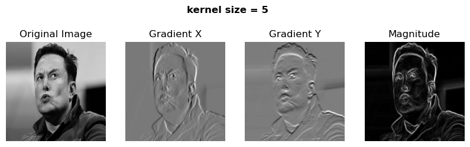

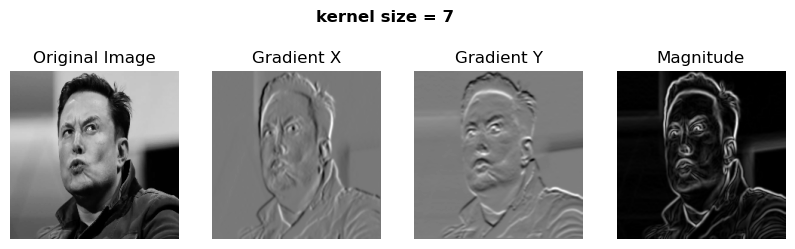

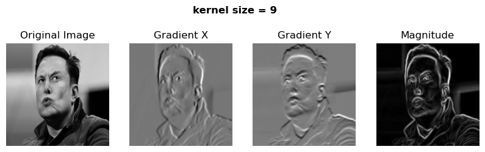

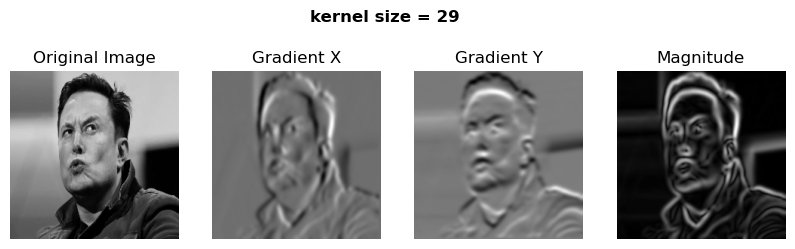

```
(-0.5, 223.5, 223.5, -0.5)
```

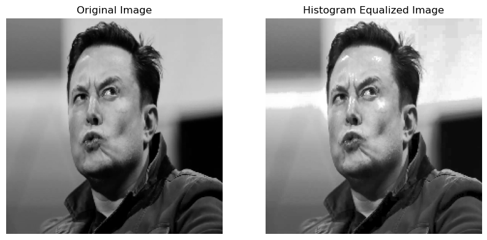

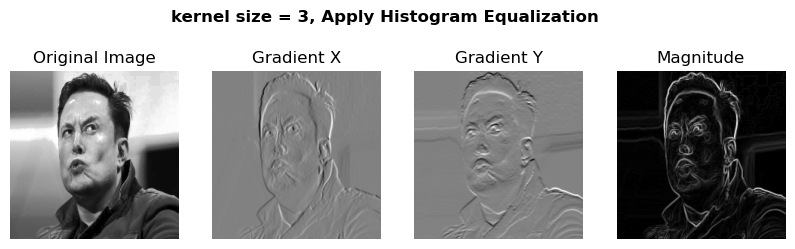

# Canny Edge Detector

[figure not shown]

[1]Canny J. A computational approach to edge detection[J]. IEEE Transactions on pattern analysis and machine intelligence, 1986 (6): 679-698.

Canny detector is a multi-stage algorithm

### The process of Canny edge detection algorithm:

1. Apply Gaussian filter to smooth the image. -> Noise Reduction
2. Finding Intensity Gradient of the image -> Magnitude and Direction
3. Non-maximum Suppression -> Make Edge Thinner
4. Double Thresholding -> Potential edges are determined by two thresholds: a high and a low threshold

## Finding Intensity Gradient of the image

[figure not shown]

## Non-maximum Suppression

After getting gradient magnitude and direction, a full scan of image is done to remove any unwanted pixels which may not constitute the edge. For this, at every pixel, pixel is checked if it is a local maximum in its neighborhood in the direction of gradient.

[figure not shown]

## Double Threshold

This stage decides which are all edges are really edges and which are not. For this, we need two threshold values, minVal and maxVal. Any edges with intensity gradient more than maxVal are sure to be edges and those below minVal are sure to be non-edges, so discarded. Those who lie between these two thresholds are classified edges or non-edges based on their connectivity. If they are connected to "sure-edge" pixels, they are considered to be part of edges. Otherwise, they are also discarded.

See the image below:

[figure not shown]

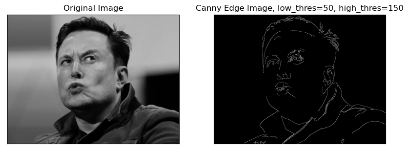

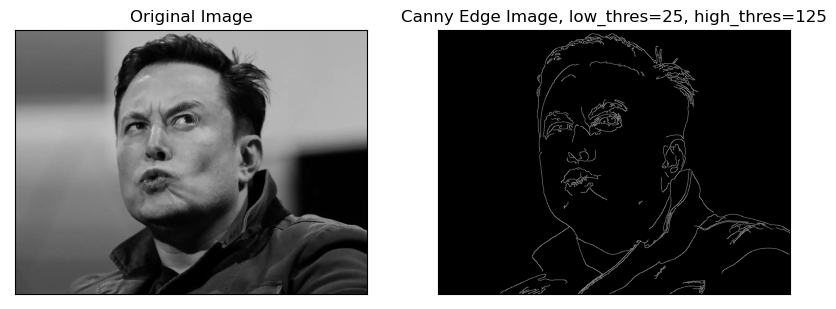

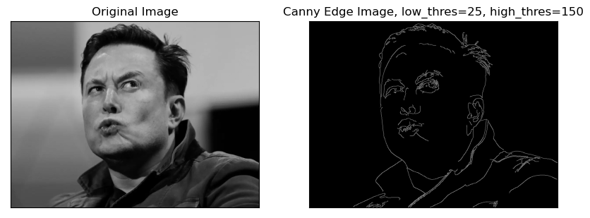

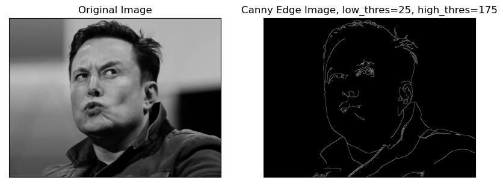

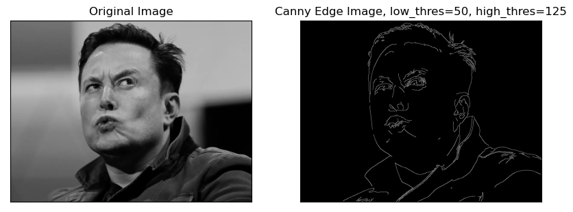

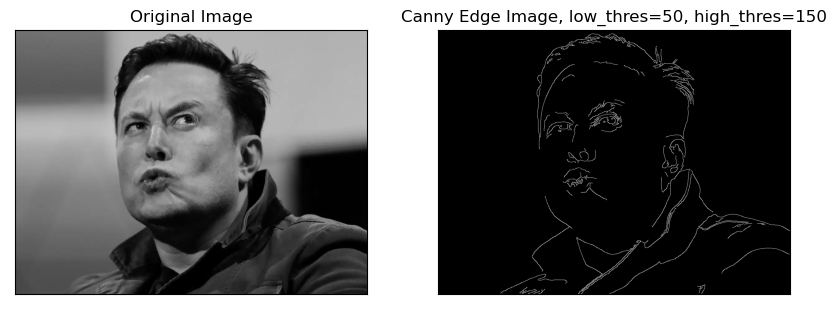

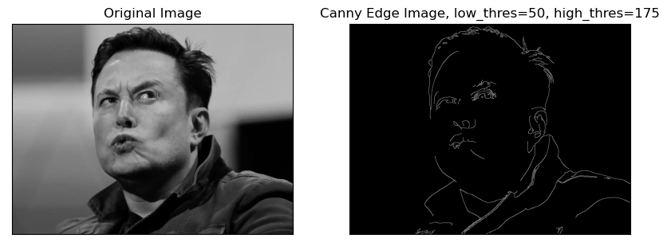

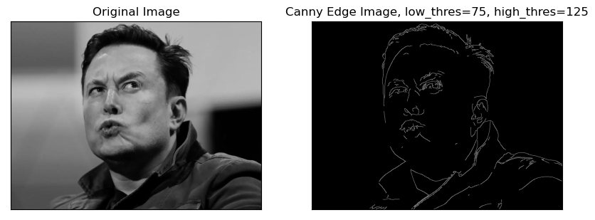

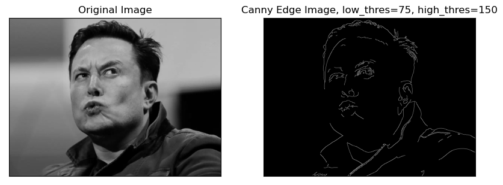

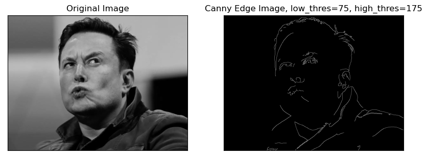